# SuGR Manual User

Welcome to SuGR (SAFIR02 Upload Gustave Roussy), the Shiny application that allows you to check, edit and submit your files on Synapse.

## 1. Log in

To log in you have to enter your Synapse User Name and Password.

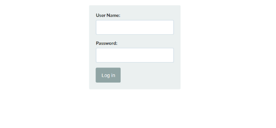

## 2. Upload your files

- You can select multiple files at the same time.
- In case you don’t see it, it means that the file you are trying to upload is not supported by SuGR. Please ensure that your file has either a “.CEL/.CEL.bz2” or a “.tsv” extension. Otherwise, the warning below will show up.

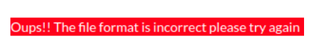

- On the side panel, you can see the list of files that will be uploaded on Synapse

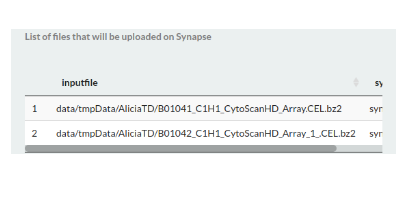

### a. CEL files

- Click on “CEL” then “Browse”

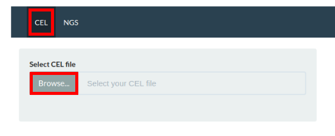

Warning: Every time you click on “Browse”, the previous list of files will be deleted.

- Select the file to be analyzed in the drop down menu

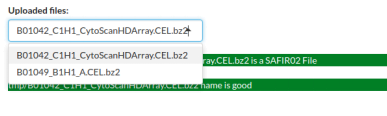

- Once all the files have been processed, click on “Upload ALL CEL on Synapse” to begin the transfer

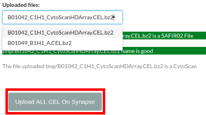

### b. NGS files

- Click on “NGS” then “Browse”

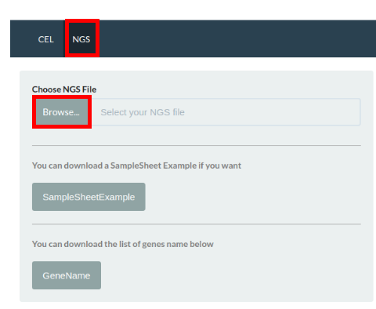

Warning: Every time you click on “Browse”, the previous list of files will be deleted.

- A discrepancy will be mark in red. You can edit the table by double clicking on the cell, select your correction in the drop down menu and type Enter after modification. You can also get some help by looking at the Sample Sheet Rules or the list of Gene Name files.

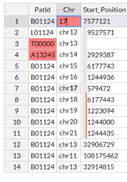

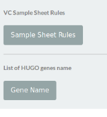

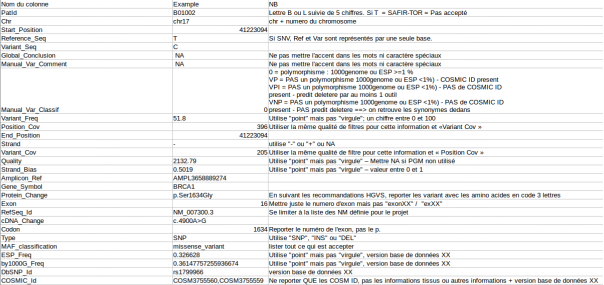

- Don’t forget to click on Save changes after editing.

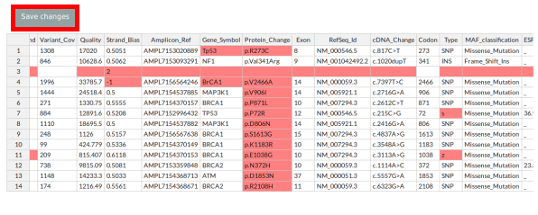

Warning: Clicking again on the file in the drop down menu will erase your modifications.

- The new version of your table can be downloaded by clicking on “Download New Table”. This version is the one edited by SuGR and yourself.

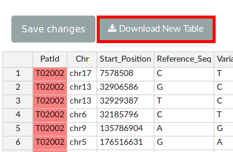

## 3. Warning color code

- Green warning = file correct. Ready to be uploaded
- Orange warning = file incorrect but the problem has been corrected (ex: space found in file name). Ready to be uploaded.  
  Note: once the file has been rename, you can not click on the file in the drop down menu. You will have to upload it again.
- Red warning = file incorrect. A new version has to be edited and/or downloaded.
- Make sure there are no red warnings before uploading on Synapse.

## 4. Disconnecting

- Click on “Close window” on the bottom of the page to disconnect from Synapse and close the app. Note: all the temp files will be deleted as well.

[figure not shown]

## 5. Contact

If you need any help or requests, please contact Alicia TRAN DIEN (alicia.tran-dien@gustaveroussy.fr) from Bioinformatics plateform.